# Informe 3 — Regresión y Análisis Exploratorio de Datos (EDA)

## 1. Contexto de negocio

**NovaConecta** ofrece planes de internet y telefonía móvil (Básico, Estándar y Premium). Estimar el CLV le permite priorizar la retención de sus clientes más valiosos, dimensionar campañas y detectar fricción operativa.

```python
import warnings
warnings.filterwarnings('ignore')
import os
import numpy as np
import pandas as pd
import matplotlib.pyplot as plt
import seaborn as sns

from sklearn.model_selection import train_test_split, cross_val_score
from sklearn.preprocessing import StandardScaler, PolynomialFeatures
from sklearn.linear_model import LinearRegression, RidgeCV, LassoCV
from sklearn.ensemble import GradientBoostingRegressor
from sklearn.pipeline import Pipeline
from sklearn.metrics import mean_squared_error, r2_score

SEED = 42
np.random.seed(SEED)
sns.set_theme(style='whitegrid')
plt.rcParams['figure.figsize'] = (10, 5)
```

## 2. Carga y revisión inicial

```python
RUTA_LOCAL = '../data/dataset_novaconecta.csv'
RUTA_GITHUB = ('https://raw.githubusercontent.com/mrcastilla8/Proyecto_IA/'
               'master/data/dataset_novaconecta.csv')

ruta = RUTA_LOCAL if os.path.exists(RUTA_LOCAL) else RUTA_GITHUB
df = pd.read_csv(ruta, encoding='utf-8')

print(f'Datos cargados desde: {ruta}')
print(f'Dimensiones: {df.shape[0]} filas x {df.shape[1]} columnas')
df.head()
```

```
Datos cargados desde: ../data/dataset_novaconecta.csv
Dimensiones: 1200 filas x 13 columnas
```

|  | id_cliente | nombre_cliente | ciudad | fecha_registro | edad | plan_contratado | antiguedad_meses | uso_datos_gb | num_llamadas_soporte | cargo_mensual | satisfaccion_cliente | valor_vida_cliente | abandono |
| --- | --- | --- | --- | --- | --- | --- | --- | --- | --- | --- | --- | --- | --- |
| 0 | NC-00001 | Albano Llopis Hierro | Alicante | 2023-12-04 | 56 | Basico | 31 | 16.4 | 4 | 30.13 | 4 | 1321.71 | No |
| 1 | NC-00002 | Buenaventura de Bonet | Badajoz | 2026-05-11 | 69 | Estandar | 2 | 48.2 | 1 | 45.18 | 8 | 174.05 | Si |
| 2 | NC-00003 | Ileana Antón-Andrés | Valencia | 2025-05-09 | 46 | Estandar | 14 | 51.0 | 2 | 59.50 | 6 | 844.68 | Si |
| 3 | NC-00004 | César Guerrero Vazquez | Palencia | 2021-09-27 | 32 | Estandar | 57 | 31.4 | 1 | 63.76 | 8 | 4427.04 | No |
| 4 | NC-00005 | Alba Mar Flor Rivas | Jaén | 2023-04-09 | 60 | Estandar | 39 | 44.3 | 2 | 59.46 | 7 | 3024.14 | No |

```python
df.info()
```

```
<class 'pandas.core.frame.DataFrame'>
RangeIndex: 1200 entries, 0 to 1199
Data columns (total 13 columns):
 #   Column                Non-Null Count  Dtype
---  ------                --------------  -----
 0   id_cliente            1200 non-null   object
 1   nombre_cliente        1200 non-null   object
 2   ciudad                1200 non-null   object
 3   fecha_registro        1200 non-null   object
 4   edad                  1200 non-null   int64
 5   plan_contratado       1200 non-null   object
 6   antiguedad_meses      1200 non-null   int64
 7   uso_datos_gb          1175 non-null   float64
 8   num_llamadas_soporte  1200 non-null   int64
 9   cargo_mensual         1200 non-null   float64
 10  satisfaccion_cliente  1200 non-null   int64
 11  valor_vida_cliente    1200 non-null   float64
 12  abandono              1200 non-null   object
dtypes: float64(3), int64(4), object(6)
memory usage: 122.0+ KB
```

```python
df['fecha_registro'] = pd.to_datetime(df['fecha_registro'])
df.describe().round(2)
```

|  | fecha_registro | edad | antiguedad_meses | uso_datos_gb | num_llamadas_soporte | cargo_mensual | satisfaccion_cliente | valor_vida_cliente |
| --- | --- | --- | --- | --- | --- | --- | --- | --- |
| count | 1200 | 1200.00 | 1200.00 | 1175.00 | 1200.00 | 1200.00 | 1200.00 | 1200.00 |
| mean | 2024-01-03 14:54:00 | 46.32 | 29.98 | 39.23 | 2.37 | 54.76 | 6.53 | 1979.15 |
| min | 2021-07-07 00:00:00 | 18.00 | 1.00 | 3.40 | 0.00 | 15.16 | 1.00 | 50.00 |
| 25% | 2022-10-08 18:00:00 | 33.00 | 15.00 | 16.20 | 1.00 | 32.73 | 5.00 | 902.14 |
| 50% | 2023-12-22 12:00:00 | 46.00 | 30.00 | 31.00 | 2.00 | 54.60 | 7.00 | 1646.66 |
| 75% | 2025-04-08 06:00:00 | 61.00 | 45.00 | 50.25 | 3.00 | 63.79 | 8.00 | 2743.14 |
| max | 2026-07-01 00:00:00 | 74.00 | 60.00 | 155.10 | 9.00 | 263.84 | 10.00 | 7434.89 |
| std | NaN | 16.45 | 17.43 | 29.80 | 1.62 | 26.94 | 1.67 | 1427.68 |

**Dataset:** 1200 clientes × 13 variables. Variable elegida a predecir: `valor_vida_cliente` (continua). Las columnas (`id_cliente`, `nombre_cliente`, `ciudad`, `fecha_registro`) se descartan por no ser predictivas.

## 3. Análisis Exploratorio de Datos (EDA)

### 3.1 Valores nulos

```python
nulos = df.isna().sum()
tabla_nulos = pd.DataFrame({
    'Nulos': nulos,
    '% del total': (nulos / len(df) * 100).round(2)
})
tabla_nulos[tabla_nulos['Nulos'] > 0]
```

|  | Nulos | % del total |
| --- | --- | --- |
| uso_datos_gb | 25 | 2.08 |

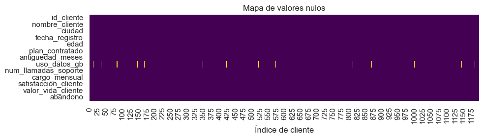

```python
fig, ax = plt.subplots(figsize=(10, 3))
sns.heatmap(df.isna().T, cbar=False, cmap='viridis', ax=ax)
ax.set_title('Mapa de valores nulos')
ax.set_xlabel('Índice de cliente')
plt.tight_layout()
plt.show()
```

Solo `uso_datos_gb` tiene nulos (25, ~2.1%): se imputarán con la **mediana** (robusta frente a outliers).

### 3.2 Valores atípicos (outliers) — regla 1.5×IQR

```python
num_cols = ['edad', 'antiguedad_meses', 'uso_datos_gb', 'num_llamadas_soporte',
            'cargo_mensual', 'satisfaccion_cliente', 'valor_vida_cliente']

def contar_outliers_iqr(serie):
    q1, q3 = serie.quantile(0.25), serie.quantile(0.75)
    iqr = q3 - q1
    lim_inf, lim_sup = q1 - 1.5 * iqr, q3 + 1.5 * iqr
    return ((serie < lim_inf) | (serie > lim_sup)).sum(), lim_inf, lim_sup

resumen_out = []
for c in num_cols:
    n_out, li, ls = contar_outliers_iqr(df[c].dropna())
    resumen_out.append({'Variable': c, 'Outliers (1.5*IQR)': n_out,
                        'Límite inferior': round(li, 2), 'Límite superior': round(ls, 2)})
pd.DataFrame(resumen_out)
```

|  | Variable | Outliers (1.5*IQR) | Límite inferior | Límite superior |
| --- | --- | --- | --- | --- |
| 0 | edad | 0 | -9.00 | 103.00 |
| 1 | antiguedad_meses | 0 | -30.00 | 90.00 |
| 2 | uso_datos_gb | 75 | -34.88 | 101.32 |
| 3 | num_llamadas_soporte | 17 | -2.00 | 6.00 |
| 4 | cargo_mensual | 8 | -13.87 | 110.39 |
| 5 | satisfaccion_cliente | 0 | 0.50 | 12.50 |
| 6 | valor_vida_cliente | 36 | -1859.36 | 5504.63 |

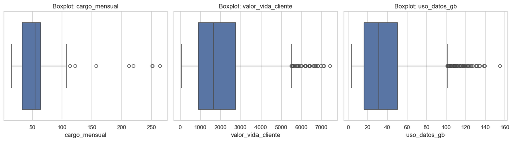

```python
fig, axes = plt.subplots(1, 3, figsize=(14, 4))
for ax, col in zip(axes, ['cargo_mensual', 'valor_vida_cliente', 'uso_datos_gb']):
    sns.boxplot(x=df[col], ax=ax, color='#4C72B0')
    ax.set_title(f'Boxplot: {col}')
plt.tight_layout()
plt.show()
```

`cargo_mensual` concentra los atípicos severos (cargos ×3-4): se **winsorizarán** al límite IQR. El target no se recorta para no sesgar el modelo.

### 3.3 Distribuciones

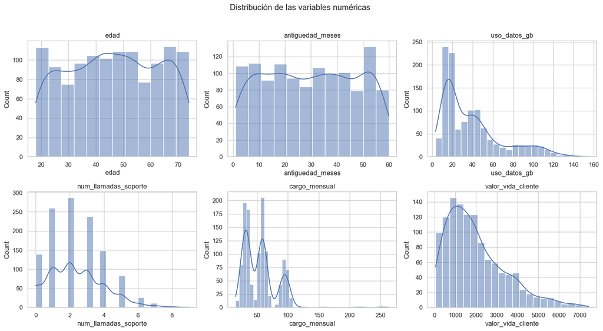

```python
fig, axes = plt.subplots(2, 3, figsize=(15, 8))
cols_hist = ['edad', 'antiguedad_meses', 'uso_datos_gb',
             'num_llamadas_soporte', 'cargo_mensual', 'valor_vida_cliente']
for ax, col in zip(axes.ravel(), cols_hist):
    sns.histplot(df[col].dropna(), kde=True, ax=ax, color='#4C72B0')
    ax.set_title(col)
plt.suptitle('Distribución de las variables numéricas', y=1.02)
plt.tight_layout()
plt.show()
```

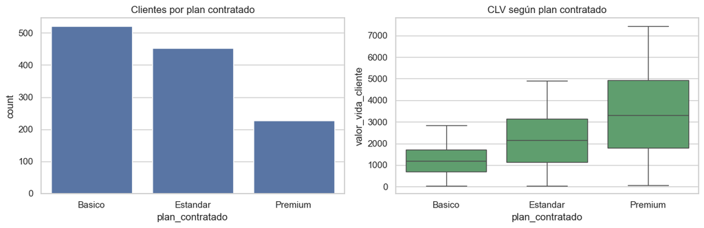

```python
fig, axes = plt.subplots(1, 2, figsize=(12, 4))
sns.countplot(data=df, x='plan_contratado', order=['Basico', 'Estandar', 'Premium'],
              ax=axes[0], color='#4C72B0')
axes[0].set_title('Clientes por plan contratado')
sns.boxplot(data=df, x='plan_contratado', y='valor_vida_cliente',
            order=['Basico', 'Estandar', 'Premium'], ax=axes[1], color='#55A868')
axes[1].set_title('CLV según plan contratado')
plt.tight_layout()
plt.show()
```

### 3.4 Correlaciones

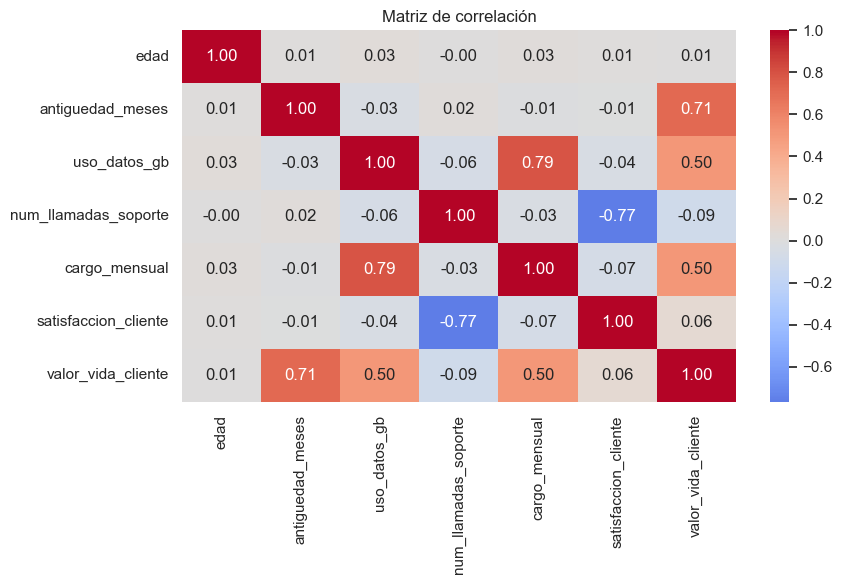

```python
matriz_corr = df[num_cols].corr()

fig, ax = plt.subplots(figsize=(9, 6))
sns.heatmap(matriz_corr, annot=True, fmt='.2f', cmap='coolwarm', center=0, ax=ax)
ax.set_title('Matriz de correlación')
plt.tight_layout()
plt.show()
```

```python
corr_target = (matriz_corr['valor_vida_cliente']
               .drop('valor_vida_cliente')
               .sort_values(key=abs, ascending=False))
corr_target.round(3)
```

```
antiguedad_meses        0.712
cargo_mensual           0.505
uso_datos_gb            0.504
num_llamadas_soporte   -0.095
satisfaccion_cliente    0.059
edad                    0.005
Name: valor_vida_cliente, dtype: float64
```

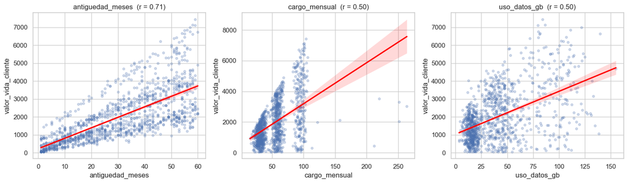

```python
top3 = corr_target.abs().sort_values(ascending=False).head(3).index

fig, axes = plt.subplots(1, 3, figsize=(15, 4.5))
for ax, col in zip(axes, top3):
    sns.regplot(data=df, x=col, y='valor_vida_cliente', ax=ax,
                scatter_kws={'alpha': 0.25, 's': 15}, line_kws={'color': 'red'})
    ax.set_title(f'{col}  (r = {corr_target[col]:.2f})')
plt.tight_layout()
plt.show()
```

## 4. Preprocesamiento

Imputación por mediana, winsorización IQR, descarte de columnas no predictivas, One-Hot de `plan_contratado`, split 80/20 (semilla 42) y `StandardScaler` ajustado solo en train.

```python
df_prep = df.copy()

mediana_uso = df_prep['uso_datos_gb'].median()
n_imputados = df_prep['uso_datos_gb'].isna().sum()
df_prep['uso_datos_gb'] = df_prep['uso_datos_gb'].fillna(mediana_uso)

q1, q3 = df_prep['cargo_mensual'].quantile([0.25, 0.75])
lim_sup = q3 + 1.5 * (q3 - q1)
n_wins = (df_prep['cargo_mensual'] > lim_sup).sum()
df_prep['cargo_mensual'] = df_prep['cargo_mensual'].clip(upper=lim_sup)

df_model = df_prep.drop(columns=['id_cliente', 'nombre_cliente', 'ciudad',
                                 'fecha_registro', 'abandono'])
df_model = pd.get_dummies(df_model, columns=['plan_contratado'], drop_first=True, dtype=int)

print(f'Nulos imputados en uso_datos_gb: {n_imputados} (mediana = {mediana_uso})')
print(f'Outliers winsorizados en cargo_mensual: {n_wins} (límite superior = {lim_sup:.2f})')
print(f'Dimensiones tras el preprocesamiento: {df_model.shape}')
df_model.head()
```

```
Nulos imputados en uso_datos_gb: 25 (mediana = 31.0)
Outliers winsorizados en cargo_mensual: 8 (límite superior = 110.39)
Dimensiones tras el preprocesamiento: (1200, 9)
```

|  | edad | antiguedad_meses | uso_datos_gb | num_llamadas_soporte | cargo_mensual | satisfaccion_cliente | valor_vida_cliente | plan_contratado_Estandar | plan_contratado_Premium |
| --- | --- | --- | --- | --- | --- | --- | --- | --- | --- |
| 0 | 56 | 31 | 16.4 | 4 | 30.13 | 4 | 1321.71 | 0 | 0 |
| 1 | 69 | 2 | 48.2 | 1 | 45.18 | 8 | 174.05 | 1 | 0 |
| 2 | 46 | 14 | 51.0 | 2 | 59.50 | 6 | 844.68 | 1 | 0 |
| 3 | 32 | 57 | 31.4 | 1 | 63.76 | 8 | 4427.04 | 1 | 0 |
| 4 | 60 | 39 | 44.3 | 2 | 59.46 | 7 | 3024.14 | 1 | 0 |

```python
X = df_model.drop(columns=['valor_vida_cliente'])
y = df_model['valor_vida_cliente']

X_train, X_test, y_train, y_test = train_test_split(X, y, test_size=0.2, random_state=SEED)
print(f'Train: {X_train.shape[0]} filas | Test: {X_test.shape[0]} filas')

scaler_demo = StandardScaler().fit(X_train)
X_train_esc = pd.DataFrame(scaler_demo.transform(X_train), columns=X.columns)
X_train_esc.describe().loc[['mean', 'std']].round(2)
```

```
Train: 960 filas | Test: 240 filas
```

|  | edad | antiguedad_meses | uso_datos_gb | num_llamadas_soporte | cargo_mensual | satisfaccion_cliente | plan_contratado_Estandar | plan_contratado_Premium |
| --- | --- | --- | --- | --- | --- | --- | --- | --- |
| mean | -0.0 | 0.0 | 0.0 | 0.0 | 0.0 | 0.0 | 0.0 | 0.0 |
| std | 1.0 | 1.0 | 1.0 | 1.0 | 1.0 | 1.0 | 1.0 | 1.0 |

## 5. Modelado

Protocolo común: **MSE, RMSE y R² en test**, R² en train (control de sobreajuste) y **CV-RMSE 5-fold**.

```python
resultados = []

def evaluar_modelo(nombre, pipeline, X_tr, X_te, y_tr, y_te):
    pipeline.fit(X_tr, y_tr)
    y_pred = pipeline.predict(X_te)

    mse = mean_squared_error(y_te, y_pred)
    rmse = np.sqrt(mse)
    r2_train = r2_score(y_tr, pipeline.predict(X_tr))
    r2_test = r2_score(y_te, y_pred)
    cv_rmse = -cross_val_score(pipeline, X_tr, y_tr, cv=5,
                               scoring='neg_root_mean_squared_error').mean()

    resultados.append({'Modelo': nombre, 'MSE': mse, 'RMSE': rmse,
                       'R2_train': r2_train, 'R2_test': r2_test,
                       'CV_RMSE_5fold': cv_rmse})
    print(f'{nombre:>22} | MSE={mse:>12,.2f} | RMSE={rmse:>8,.2f} | '
          f'R2 train={r2_train:.4f} | R2 test={r2_test:.4f} | CV-RMSE={cv_rmse:>8,.2f}')
    return pipeline
```

### 5.1 Regresión Lineal Simple

```
Predictor: antiguedad_meses (r = 0.712)

         Lineal Simple | MSE=1,047,842.05 | RMSE=1,023.64 | R2 train=0.5110 | R2 test=0.4896 | CV-RMSE=  998.38
```

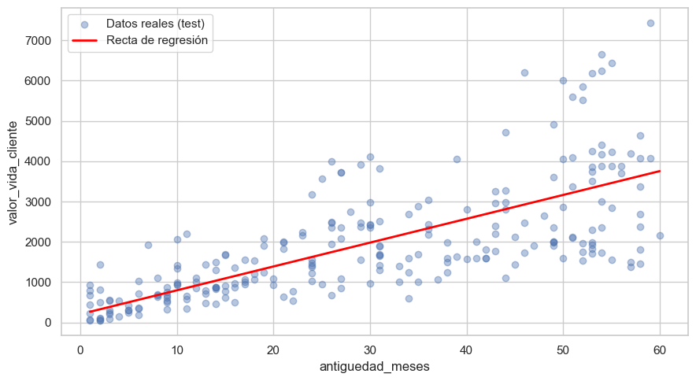

```python
mejor_feature = corr_target.abs().idxmax()
print(f'Predictor: {mejor_feature} (r = {corr_target[mejor_feature]:.3f})\n')

pipe_simple = Pipeline([('escala', StandardScaler()), ('modelo', LinearRegression())])
pipe_simple = evaluar_modelo('Lineal Simple', pipe_simple,
                             X_train[[mejor_feature]], X_test[[mejor_feature]],
                             y_train, y_test)

fig, ax = plt.subplots(figsize=(9, 5))
ax.scatter(X_test[mejor_feature], y_test, alpha=0.4, label='Datos reales (test)')
orden = X_test[[mejor_feature]].sort_values(mejor_feature)
ax.plot(orden[mejor_feature], pipe_simple.predict(orden), color='red',
        linewidth=2, label='Recta de regresión')
ax.set_xlabel(mejor_feature)
ax.set_ylabel('valor_vida_cliente')
ax.legend()
plt.tight_layout()
plt.show()
```

### 5.2 Regresión Lineal Múltiple

```
       Lineal Múltiple | MSE=  378,790.62 | RMSE=  615.46 | R2 train=0.8507 | R2 test=0.8155 | CV-RMSE=  558.43
```

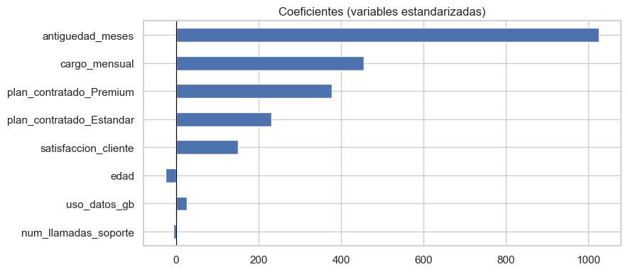

```python
pipe_multiple = Pipeline([('escala', StandardScaler()), ('modelo', LinearRegression())])
pipe_multiple = evaluar_modelo('Lineal Múltiple', pipe_multiple,
                               X_train, X_test, y_train, y_test)

coef_mult = pd.Series(pipe_multiple.named_steps['modelo'].coef_, index=X.columns)
fig, ax = plt.subplots(figsize=(9, 4))
coef_mult.sort_values(key=abs).plot(kind='barh', ax=ax, color='#4C72B0')
ax.axvline(0, color='black', linewidth=0.8)
ax.set_title('Coeficientes (variables estandarizadas)')
plt.tight_layout()
plt.show()
```

### 5.3 Regresión Polinómica — grado seleccionado por validación cruzada

```python
cv_por_grado = {}
for g in [1, 2, 3]:
    pipe = Pipeline([('escala', StandardScaler()),
                     ('poli', PolynomialFeatures(degree=g, include_bias=False)),
                     ('modelo', LinearRegression())])
    cv_por_grado[g] = -cross_val_score(pipe, X_train, y_train, cv=5,
                                       scoring='neg_root_mean_squared_error').mean()

seleccion = pd.Series(cv_por_grado, name='CV_RMSE').rename_axis('Grado').round(2)
grado_optimo = seleccion.idxmin()
print(seleccion.to_string())
print(f'\nGrado seleccionado: {grado_optimo} (menor CV-RMSE)')
```

```
Grado
1    558.43
2    324.08
3    408.32

Grado seleccionado: 2 (menor CV-RMSE)
```

```python
pipe_poli = Pipeline([
    ('escala', StandardScaler()),
    ('poli', PolynomialFeatures(degree=grado_optimo, include_bias=False)),
    ('modelo', LinearRegression()),
])
pipe_poli = evaluar_modelo(f'Polinómica (grado {grado_optimo})', pipe_poli,
                           X_train, X_test, y_train, y_test)
```

```
  Polinómica (grado 2) | MSE=  102,017.45 | RMSE=  319.40 | R2 train=0.9570 | R2 test=0.9503 | CV-RMSE=  324.08
```

### 5.4 Ridge (L2) — alpha por validación cruzada

```python
pipe_ridge = Pipeline([('escala', StandardScaler()),
                       ('modelo', RidgeCV(alphas=[0.01, 0.1, 1, 10, 100, 500], cv=5))])
pipe_ridge = evaluar_modelo('Ridge', pipe_ridge, X_train, X_test, y_train, y_test)
print(f"\nAlpha seleccionado: {pipe_ridge.named_steps['modelo'].alpha_}")
```

```
                 Ridge | MSE=  377,869.98 | RMSE=  614.71 | R2 train=0.8506 | R2 test=0.8160 | CV-RMSE=  557.57

Alpha seleccionado: 10.0
```

### 5.5 Lasso (L1) — selector automático de variables

```
                 Lasso | MSE=  378,650.59 | RMSE=  615.35 | R2 train=0.8507 | R2 test=0.8156 | CV-RMSE=  558.36

Alpha seleccionado: 1.0191
```

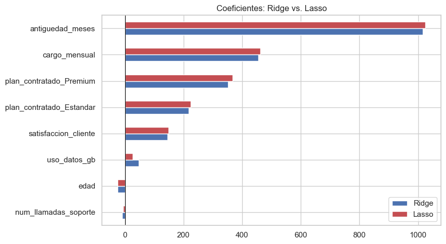

```
Variables descartadas por Lasso: ninguna
```

```python
pipe_lasso = Pipeline([('escala', StandardScaler()),
                       ('modelo', LassoCV(cv=5, random_state=SEED))])
pipe_lasso = evaluar_modelo('Lasso', pipe_lasso, X_train, X_test, y_train, y_test)
print(f"\nAlpha seleccionado: {pipe_lasso.named_steps['modelo'].alpha_:.4f}")

comparacion_coefs = pd.DataFrame({
    'Ridge': pipe_ridge.named_steps['modelo'].coef_,
    'Lasso': pipe_lasso.named_steps['modelo'].coef_,
}, index=X.columns)

fig, ax = plt.subplots(figsize=(9, 5))
comparacion_coefs.sort_values('Ridge', key=abs).plot(kind='barh', ax=ax,
                                                     color=['#4C72B0', '#C44E52'])
ax.axvline(0, color='black', linewidth=0.8)
ax.set_title('Coeficientes: Ridge vs. Lasso')
plt.tight_layout()
plt.show()

descartadas = comparacion_coefs[comparacion_coefs['Lasso'] == 0].index.tolist()
print(f'Variables descartadas por Lasso: {descartadas if descartadas else "ninguna"}')
```

### 5.6 Modelo avanzado: Gradient Boosting

```
     Gradient Boosting | MSE=  127,689.01 | RMSE=  357.34 | R2 train=0.9767 | R2 test=0.9378 | CV-RMSE=  341.45
```

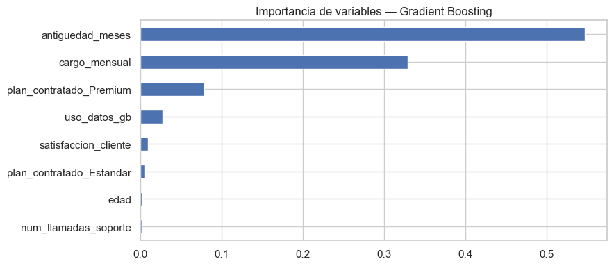

```python
pipe_gb = Pipeline([
    ('escala', StandardScaler()),
    ('modelo', GradientBoostingRegressor(n_estimators=300, learning_rate=0.05,
                                         max_depth=3, random_state=SEED)),
])
pipe_gb = evaluar_modelo('Gradient Boosting', pipe_gb, X_train, X_test, y_train, y_test)

importancias = pd.Series(pipe_gb.named_steps['modelo'].feature_importances_, index=X.columns)
fig, ax = plt.subplots(figsize=(9, 4))
importancias.sort_values().plot(kind='barh', ax=ax, color='#4C72B0')
ax.set_title('Importancia de variables — Gradient Boosting')
plt.tight_layout()
plt.show()
```

## 6. Comparación de modelos

`Brecha_R2` = R² train − R² test (cercana a 0 ⇒ buena generalización).

```python
tabla = pd.DataFrame(resultados)
tabla['Brecha_R2'] = tabla['R2_train'] - tabla['R2_test']
tabla = (tabla.sort_values('R2_test', ascending=False)
         .reset_index(drop=True)
         .round({'MSE': 2, 'RMSE': 2, 'R2_train': 4, 'R2_test': 4,
                 'CV_RMSE_5fold': 2, 'Brecha_R2': 4}))
tabla
```

|  | Modelo | MSE | RMSE | R2_train | R2_test | CV_RMSE_5fold | Brecha_R2 |
| --- | --- | --- | --- | --- | --- | --- | --- |
| 0 | Polinómica (grado 2) | 102017.45 | 319.40 | 0.9570 | 0.9503 | 324.08 | 0.0066 |
| 1 | Gradient Boosting | 127689.01 | 357.34 | 0.9767 | 0.9378 | 341.45 | 0.0389 |
| 2 | Ridge | 377869.98 | 614.71 | 0.8506 | 0.8160 | 557.57 | 0.0346 |
| 3 | Lasso | 378650.59 | 615.35 | 0.8507 | 0.8156 | 558.36 | 0.0351 |
| 4 | Lineal Múltiple | 378790.62 | 615.46 | 0.8507 | 0.8155 | 558.43 | 0.0352 |
| 5 | Lineal Simple | 1047842.05 | 1023.64 | 0.5110 | 0.4896 | 998.38 | 0.0214 |

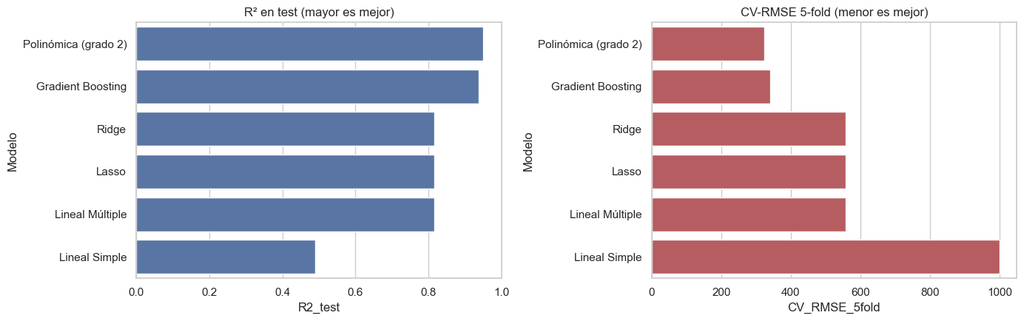

```python
fig, axes = plt.subplots(1, 2, figsize=(14, 4.5))
sns.barplot(data=tabla, y='Modelo', x='R2_test', ax=axes[0], color='#4C72B0')
axes[0].set_title('R² en test (mayor es mejor)')
axes[0].set_xlim(0, 1)
sns.barplot(data=tabla, y='Modelo', x='CV_RMSE_5fold', ax=axes[1], color='#C44E52')
axes[1].set_title('CV-RMSE 5-fold (menor es mejor)')
plt.tight_layout()
plt.show()
```

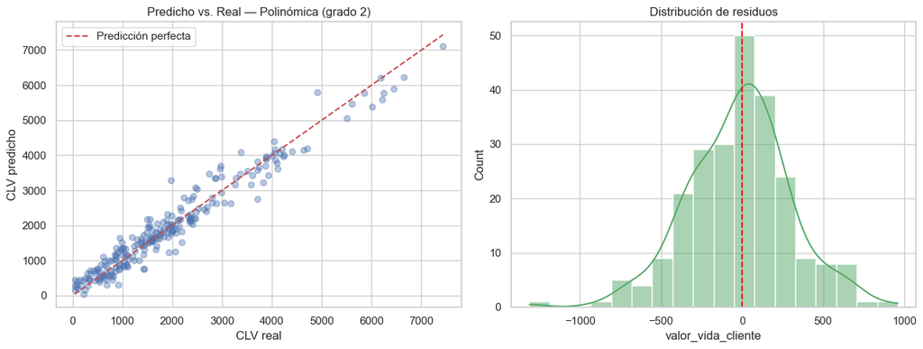

```
Mejor modelo: Polinómica (grado 2)
Residuo promedio: -18.30 | Desv. estándar: 319.54
```

```python
pipes = {'Lineal Simple': pipe_simple, 'Lineal Múltiple': pipe_multiple,
         f'Polinómica (grado {grado_optimo})': pipe_poli, 'Ridge': pipe_ridge,
         'Lasso': pipe_lasso, 'Gradient Boosting': pipe_gb}
nombre_mejor = tabla.loc[0, 'Modelo']
pipe_mejor = pipes[nombre_mejor]

X_te_mejor = X_test[[mejor_feature]] if nombre_mejor == 'Lineal Simple' else X_test
y_pred_mejor = pipe_mejor.predict(X_te_mejor)
residuos = y_test - y_pred_mejor

fig, axes = plt.subplots(1, 2, figsize=(13, 5))
axes[0].scatter(y_test, y_pred_mejor, alpha=0.4)
lims = [min(y_test.min(), y_pred_mejor.min()), max(y_test.max(), y_pred_mejor.max())]
axes[0].plot(lims, lims, 'r--', label='Predicción perfecta')
axes[0].set_xlabel('CLV real')
axes[0].set_ylabel('CLV predicho')
axes[0].set_title(f'Predicho vs. Real — {nombre_mejor}')
axes[0].legend()

sns.histplot(residuos, kde=True, ax=axes[1], color='#55A868')
axes[1].axvline(0, color='red', linestyle='--')
axes[1].set_title('Distribución de residuos')
plt.tight_layout()
plt.show()

print(f'Mejor modelo: {nombre_mejor}')
print(f'Residuo promedio: {residuos.mean():.2f} | Desv. estándar: {residuos.std():.2f}')
```

## 7. Conclusiones

**Técnicas:**

- El grado polinómico y los alphas de Ridge/Lasso se seleccionaron por validación cruzada.
- El mejor modelo es la **Polinómica grado 2**, con brecha train/test mínima (sin sobreajuste); los modelos no lineales superan a los lineales por las curvaturas que introducen los recortes de rango del dataset.

## Anexo — Registro de Prompts (Informe 3)

[output not shown]